# Project Report

# 1. Importing Packages

## Hotspots

Let's identify which countries have the highest number of total cases and active cases. This can help us understand which countries are currently experiencing the most severe outbreaks and may need additional resources to manage the pandemic.

## 1.1 Which Countries have the most reported cases of covid?

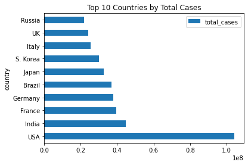

## 2 Which Countries have the least reported cases of covid?

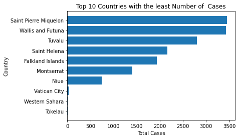

## 3 Which countries have the highest ongoing cases of covid?

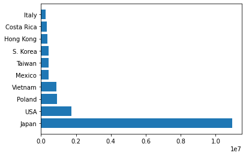

## 4 Is there correlation between Population of a country and the reported Covid Cases?

This is interesting. Let's find out if the Countries with higher population experience more test cases

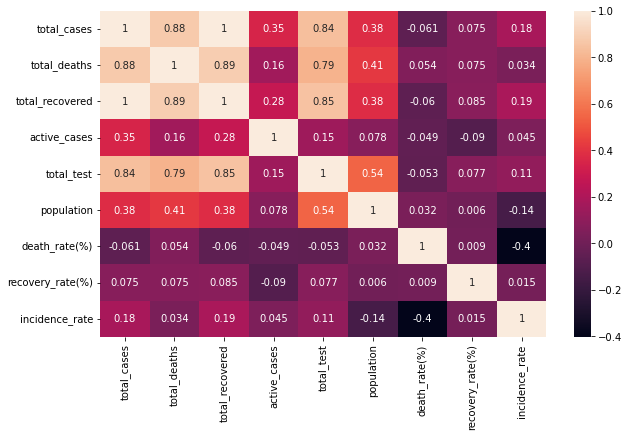

Although there is a correlation between `population` and `total_cases` in a country, it is still very weak and unrealiable. However, There are strong correlation between the following columns:

- `total_deaths` and `total_cases`
- `total_test` and `total_cases`
- `total_test` and `total_recovered`
- `total_cases` and `total_recovered`
- `total_deaths` and `total_recovered`

There is a pretty strong correleration between Total cases and Total test columns. It looks like more test were carried out in countries with high cases of the pandemic.

There is also a strong correlation between the Total number of cases and deaths. It looks that more people died of the pandemic in countries with high cases of covid-19

## Mortality rates

We can calculate the death rate for each country, which is the ratio of total deaths to total cases. This will help us identify which countries have the highest mortality rates and which countries may need additional support in managing the pandemic.

## 5. Which Countries have the highest Mortality rate?

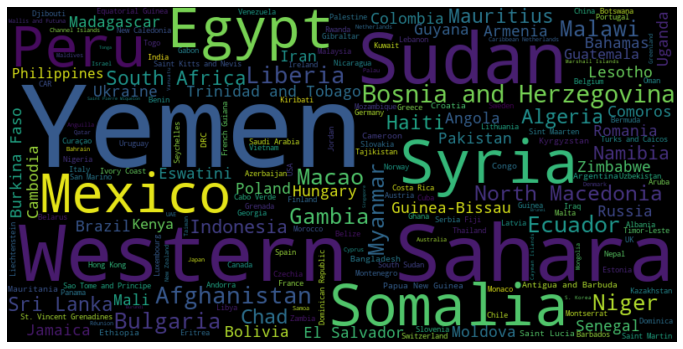

## 6 Which countries have the highest recovery rate?

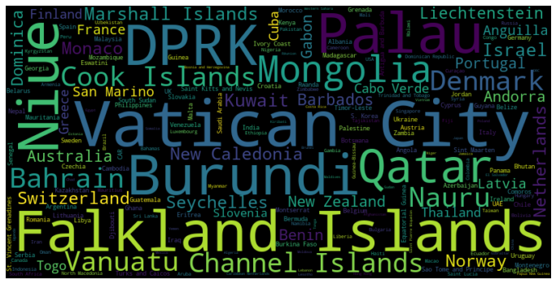

# Demographic Impact of the Pandemic

Yes, calculating the number of cases and deaths per capita can help identify the demographic impact of COVID-19 on different populations. By dividing the total number of cases and deaths by the population of each country, you can obtain a measure of the relative impact of the disease on different populations.

For example, if Country A has a high number of total cases but also a high population, it may not be as severely affected as Country B, which has a similar number of total cases but a much smaller population. Similarly, if Country C has a high number of total deaths but also a high population, its mortality rate may be lower than Country D, which has a similar number of total deaths but a smaller population.

By calculating the number of cases and deaths per capita, you can also identify which demographic groups may be more vulnerable to the disease. For instance, if a country has a high number of cases and deaths per capita among older adults, this may indicate that this age group is more vulnerable to the disease. Similarly, if a country has a high number of cases and deaths per capita among people with pre-existing conditions, this may indicate that this group is at higher risk.

Analyzing the demographic impact of COVID-19 can help public health officials and policymakers understand which populations are most affected by the disease and target their efforts to protect these groups.

## 7 Which countries have the most incidence rate?

This measures the number of new cases per population over a certain time period (usually per 100,000 people). The incidence rate can provide several insights into the spread and impact of COVID-19, such as:

- Severity of the outbreak: The incidence rate can indicate the severity of the COVID-19 outbreak in a particular country or region. Higher incidence rates suggest that the virus is spreading more rapidly in the population, which could result in a higher burden on healthcare systems and potentially more deaths.

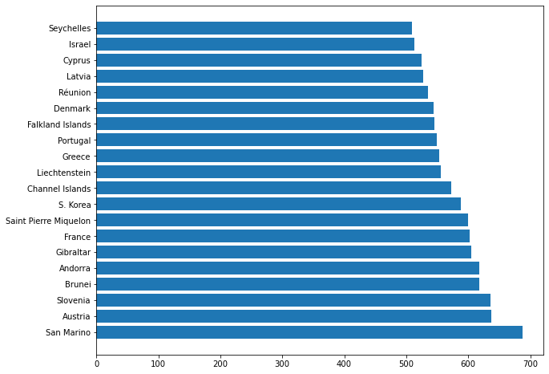

[output not shown]